# Piotr Dyba Assignment 2

Piotr Dyba

2022-12-15

#ZAD 1_A

```r
zad1_1 <- c(5.5,5.61,4.88,5.07,5.26,5.55,5.36,5.29,5.58,5.65,5.57,5.53,5.62,5.29,5.44,5.34,5.79,5.1,5.27,5.39,5.42,5.47,5.63,5.34,5.46,5.3,5.75,5.68,5.85)
mean_density = round(mean(zad1_1),3)
```

#ZAD 1_B

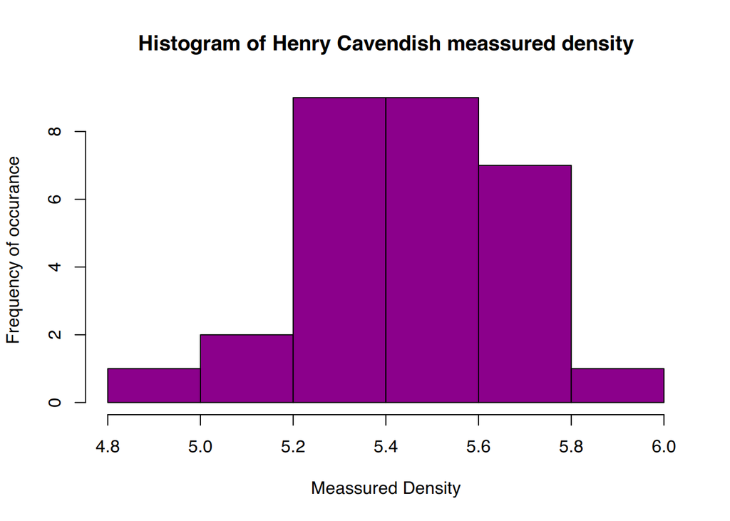

```r
hist(zad1_1,
      xlab = 'Meassured Density',
      ylab = 'Frequency of occurance',
      main = 'Histogram of Henry Cavendish meassured density',
      col='darkmagenta')
```

#ZAD 1_C

We should use the t-test in order to perform hypothesis testing because at that point the population variance is unknown to us

#ZAD 1_D

```r
t.test(zad1_1)$"conf.int"
```

```
## [1] 5.363888 5.531974
## attr(,"conf.level")
## [1] 0.95
```

#ZAD 1_E

```r
c1_1 <- t.test(zad1_1, mu=5.5,alternative = "less")
c1_1
```

```
##
##  One Sample t-test
##
## data:  zad1_1
## t = -1.2691, df = 28, p-value = 0.1074
## alternative hypothesis: true mean is less than 5.5
## 95 percent confidence interval:
##      -Inf 5.517726
## sample estimates:
## mean of x
##  5.447931
```

p-value is greater than 0.05 so we fall to reject the h_0 and there is no evidence to support H_1.

#ZAD 2

```r
t.test(iris$Sepal.Width ~ iris$Species, subset = iris$Species%in%c("virginica","versicolor"))
```

```
##
##  Welch Two Sample t-test
##
## data:  iris$Sepal.Width by iris$Species
## t = -3.2058, df = 97.927, p-value = 0.001819
## alternative hypothesis: true difference in means between group versicolor and group virginica is not equal to 0
## 95 percent confidence interval:
##  -0.33028364 -0.07771636
## sample estimates:
## mean in group versicolor  mean in group virginica
##                    2.770                    2.974
```

The function above is performing a hypothesis in which it is testing what could be the true difference in means between group versicolor and group virginica. This is the welch two sample t-test the p-value is lower than 0.05 so we reject the null hypothesis h_0 and there is evidence to support the alternative hypothesis H_1.

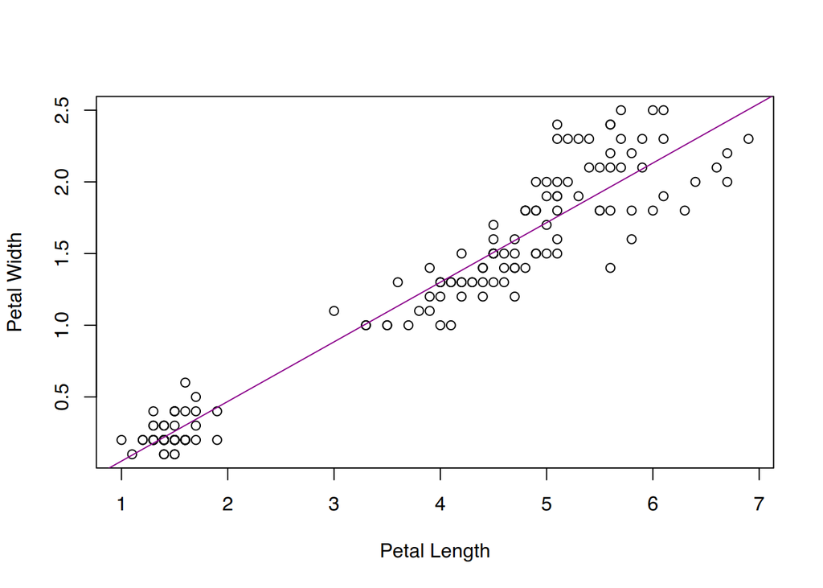

```r
model <- lm(iris$Petal.Width ~ iris$Petal.Length)
plot(iris$Petal.Length, iris$Petal.Width,ylab = 'Petal Width',xlab='Petal Length')
abline(model, col = "darkmagenta")
```

```r
summary(model)$r.squared
```

```
## [1] 0.9271098
```

Based on the fact that the r^2 is equal to 0.9271098 we can conclude that the model explains the majority of the variation response variable because it is really close to 1

```r
omnivores<-c(0.78, 0.80, 0.76, 0.78, 0.58, 0.64, 0.92, 0.86, 0.62, 0.54, 0.46)
vegetarians<-c(0.50, 0.32, 0.78, 0.68, 0.46, 0.32, 0.50, 0.68, 0.32, 0.86, 0.40, 0.36, 0.44, 0.62, 0.26)


m_omnivores <- qchisq(0.05/2, length(omnivores) - 1)
M_omnivores <- qchisq(1 - 0.05/2, length(omnivores) - 1)
m_vegetarians <- qchisq(0.05/2, length(vegetarians) - 1)
M_vegetarians <- qchisq(1 - 0.05/2, length(vegetarians) - 1)

omnivores_variance = var(omnivores)
vegetarians_variance = var(vegetarians)
omnivores_sample_standard_deviation = sqrt(omnivores_variance)
vegetarians_sample_standard_deviation = sqrt(vegetarians_variance)

lower_bound_population_var_omnivores_1 = ((length(omnivores)-1)*omnivores_sample_standard_deviation^2)/M_omnivores
upper_bound_population_var_omnivores_1 = ((length(omnivores)-1)*omnivores_sample_standard_deviation^2)/m_omnivores


lower_bound_population_var_vegetarians_1 = ((length(vegetarians)-1)*vegetarians_sample_standard_deviation^2)/M_vegetarians
upper_bound_population_var_vegetarians_1 = ((length(vegetarians)-1)*vegetarians_sample_standard_deviation^2)/m_vegetarians


lower_bound_population_var_omnivores_2 =sqrt(lower_bound_population_var_omnivores_1)
upper_bound_population_var_omnivores_2 = sqrt(upper_bound_population_var_omnivores_1)
lower_bound_population_var_vegetarians_2 = sqrt(lower_bound_population_var_vegetarians_1)
upper_bound_population_var_vegetarians_2 = sqrt(upper_bound_population_var_vegetarians_1)

print('lower and upper bounds for population variance for omnivores')
```

```
## [1] "lower and upper bounds for population variance for omnivores"
```

```r
lower_bound_population_var_omnivores_1
```

```
## [1] 0.01014757
```

```r
upper_bound_population_var_omnivores_1
```

```
## [1] 0.06401487
```

```r
print('lower and upper bounds for population variance for vegeterians')
```

```
## [1] "lower and upper bounds for population variance for vegeterians"
```

```r
lower_bound_population_var_vegetarians_1
```

```
## [1] 0.01825495
```

```r
upper_bound_population_var_vegetarians_1
```

```
## [1] 0.08470833
```

```r
print('lower and upper bounds for standard deviance for omnivores')
```

```
## [1] "lower and upper bounds for standard deviance for omnivores"
```

```r
lower_bound_population_var_omnivores_2
```

```
## [1] 0.1007352
```

```r
upper_bound_population_var_omnivores_2
```

```
## [1] 0.2530116
```

```r
print('lower and upper bounds for standard deviance for vegetarians')
```

```
## [1] "lower and upper bounds for standard deviance for vegetarians"
```

```r
lower_bound_population_var_vegetarians_2
```

```
## [1] 0.1351109
```

```r
upper_bound_population_var_vegetarians_2
```

```
## [1] 0.291047
```

```r
confidence_interval_variance_omnivores_min <- ((length(omnivores)-1)* omnivores_variance^2) / M_omnivores
confidence_interval_variance_omnivores_max <- ((length(omnivores)-1)* omnivores_variance^2) / m_omnivores
confidence_interval_standard_deviation_omnivores_min <- sqrt(confidence_interval_variance_omnivores_min)
confidence_interval_standard_deviation_omnivores_max <- sqrt(confidence_interval_variance_omnivores_max)

confidence_interval_variance_vegetarians_min <- ((length(vegetarians)-1)* vegetarians_variance^2) / M_vegetarians
confidence_interval_variance_vegetarians_max <- ((length(vegetarians)-1)* vegetarians_variance^2) / m_vegetarians
confidence_interval_standard_deviation_vegetarians_min <- sqrt(confidence_interval_variance_vegetarians_min)
confidence_interval_standard_deviation_vegetarians_max <- sqrt(confidence_interval_variance_vegetarians_max)

cat('confidence interval variance for omnivores: ','[', paste(confidence_interval_variance_omnivores_min, confidence_interval_variance_omnivores_max, sep=':'),']')
```

```
## confidence interval variance for omnivores:  [ 0.000210921925471747:0.0013305782028442 ]
```

```r
cat("\n")
```

```r
cat('confidence interval standard deviation for omnivores: ','[', paste(confidence_interval_standard_deviation_omnivores_min,confidence_interval_standard_deviation_omnivores_max, sep=':'),']')
```

```
## confidence interval standard deviation for omnivores:  [ 0.0145231513615932:0.0364770914800536 ]
```

```r
cat("\n")
```

```r
cat('confidence interval variance for vegetarians: ','[', paste(confidence_interval_variance_vegetarians_min,confidence_interval_variance_vegetarians_max, sep=':'),']')
```

```
## confidence interval variance for vegetarians:  [ 0.000621711321845178:0.0028849237673008 ]
```

```r
cat("\n")
```

```r
cat('confidence interval standard deviation for vegetarians: ','[', paste(confidence_interval_standard_deviation_vegetarians_min,confidence_interval_standard_deviation_vegetarians_max , sep=':'),']')
```

```
## confidence interval standard deviation for vegetarians:  [ 0.0249341396852825:0.0537114863627958 ]
```

```r
cat("\n")
```